# Primary School Completion Analysis: Gender Disparities in Global Education

Data Analysis Report

2025-10-22

# Data Overview

This report analyzes primary school completion rates for boys and girls across different countries in 2020. The data provides insights into global educational achievements and gender disparities in primary education completion.

```
## Number of countries with boys completion data in 2020: 42
```

```
## Number of countries with girls completion data in 2020: 44
```

The datasets contain primary school completion percentages for boys and girls across different countries. After filtering for 2020 data and removing missing values, we have data for multiple countries with completion rates.

# Primary School Completion for Girls

## Statistical Overview

Summary Statistics for Girls Primary School Completion (2020)

| mean_rate | median_rate | min_rate | max_rate | sd_rate |
| --- | --- | --- | --- | --- |
| 94.44 | 98.63 | 42.79 | 100 | 12.47 |

The analysis shows significant variation in primary school completion rates for girls across different countries, with rates ranging from very low percentages in some regions to near-complete completion in others.

Countries with Highest Girls Completion Rates (2020)

| geo | name | completion_rate |
| --- | --- | --- |
| rus | Russia | 100.000 |
| arm | Armenia | 99.885 |
| nor | Norway | 99.810 |
| est | Estonia | 99.760 |
| dnk | Denmark | 99.660 |

Countries with Lowest Girls Completion Rates (2020)

| geo | name | completion_rate |
| --- | --- | --- |
| mli | Mali | 42.79000 |
| mwi | Malawi | 54.02106 |
| gmb | Gambia | 66.55367 |
| rwa | Rwanda | 67.72837 |
| ken | Kenya | 81.67189 |

The countries with the highest and lowest girls completion rates are shown in the tables above. It’s important to note that further analyses should include population statistics to better understand the absolute number of children affected.

## Distribution Analysis

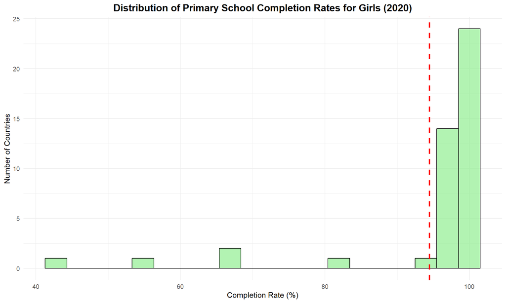

## World Map Visualization

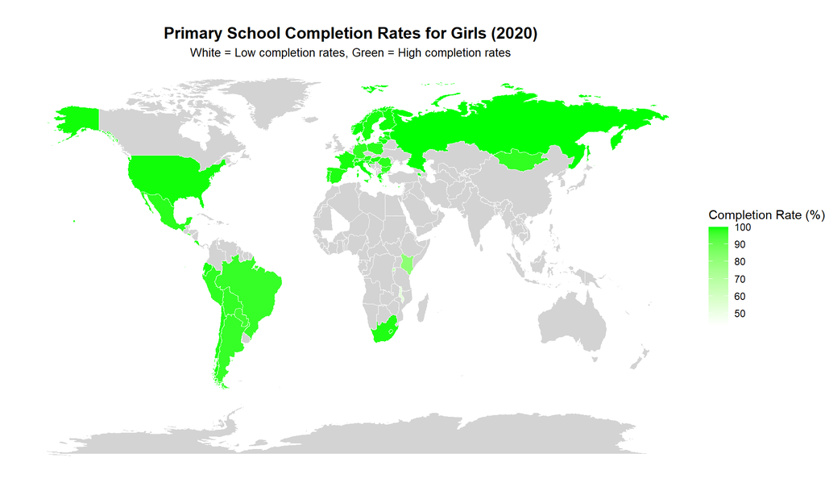

# Primary School Completion for Boys

## Statistical Overview

Summary Statistics for Boys Primary School Completion (2020)

| mean_rate | median_rate | min_rate | max_rate | sd_rate |
| --- | --- | --- | --- | --- |
| 92.68 | 97.9 | 44.87 | 99.84 | 13.86 |

The analysis shows similar variation in primary school completion rates for boys across different countries, with rates ranging from very low percentages in some regions to near-complete completion in others.

Countries with Highest Boys Completion Rates (2020)

| geo | name | completion_rate |
| --- | --- | --- |
| lva | Latvia | 99.84500 |
| svn | Slovenia | 99.80000 |
| ita | Italy | 99.63500 |
| arm | Armenia | 99.48539 |
| usa | USA | 99.47306 |

Countries with Lowest Boys Completion Rates (2020)

| geo | name | completion_rate |
| --- | --- | --- |
| mwi | Malawi | 44.86843 |
| mli | Mali | 49.29000 |
| rwa | Rwanda | 57.46405 |
| gmb | Gambia | 60.62718 |
| ken | Kenya | 74.02484 |

The countries with the highest and lowest boys completion rates are shown in the tables above. The patterns are similar to those observed for girls, suggesting that educational challenges affect both genders in similar regions.

## Distribution Analysis

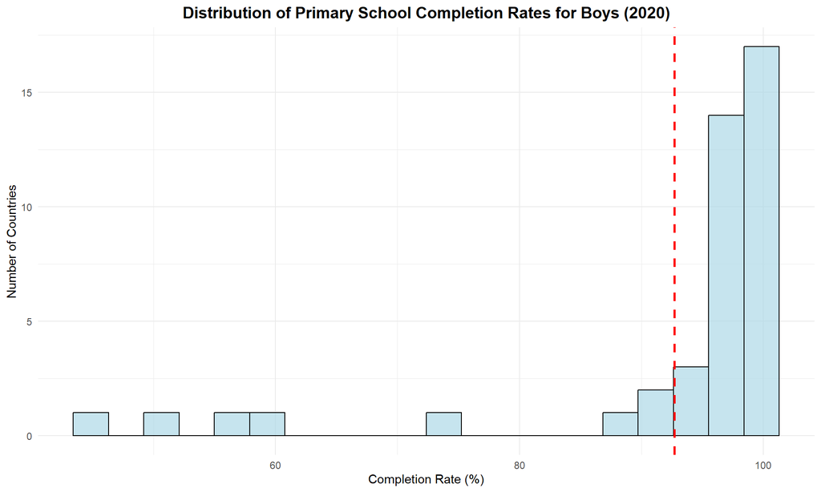

The distribution for boys shows a similar pattern to girls, with most countries achieving completion rates above 80%. The mean completion rates for boys and girls are generally comparable, with slight variations between countries.

## World Map Visualization

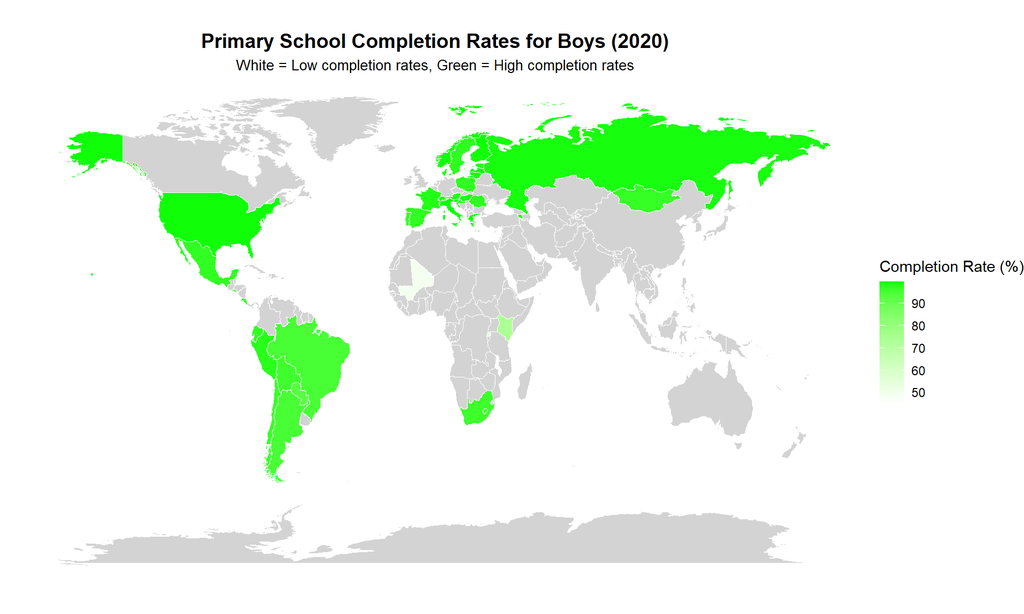

# Correlation and Regression Analysis

## Relationship Between Boys and Girls Completion Rates

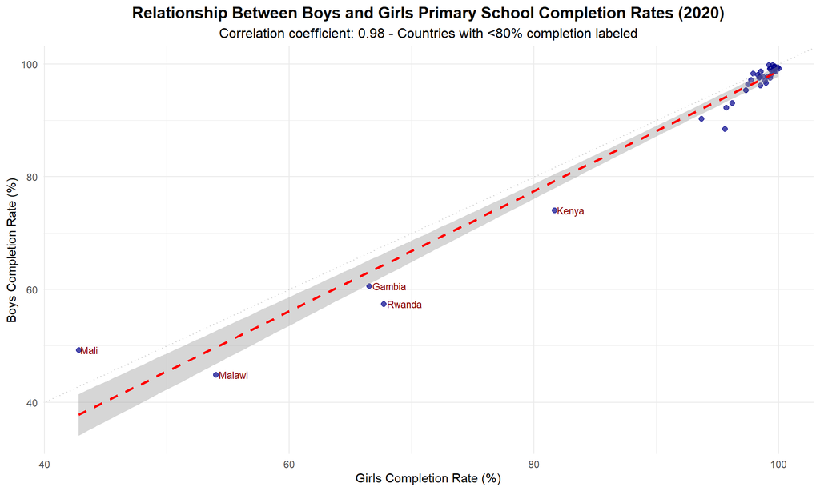

## Statistical Analysis

```
## Linear Regression Results:
```

```
## R-squared: 0.961
```

```
## Adjusted R-squared: 0.96
```

```
## F-statistic: 962.54
```

```
## p-value: 4.212541e-29
```

Regression Coefficients

|  | Estimate | Std. Error | t value | Pr(>\|t\|) |
| --- | --- | --- | --- | --- |
| (Intercept) | -7.840059 | 3.2652766 | -2.40104 | 0.0212151 |
| completion_rate_girls | 1.065872 | 0.0343555 | 31.02484 | 0.0000000 |

## Interpretation

The analysis reveals a strong positive correlation between boys’ and girls’ primary school completion rates. This indicates that countries with higher completion rates for girls also tend to have higher completion rates for boys, and vice versa.

The linear regression model shows a strong relationship between the two indicators, with the regression coefficient indicating that changes in girls’ completion rates are closely associated with changes in boys’ completion rates.

This strong relationship suggests that educational policies and infrastructure improvements benefit both genders similarly. Countries that successfully improve primary education access and quality tend to see improvements for both boys and girls, indicating that gender-specific barriers, while present, are secondary to broader systemic educational challenges.

The scatterplot shows that most countries cluster around the diagonal line (where boys and girls rates are equal), with some countries showing slight gender disparities in either direction. This pattern suggests that while gender parity is generally achieved in most countries, there are still some regions where targeted interventions may be needed to address specific gender gaps.

## Personal Reflection

I have mainly two ideas.

First, I am amazed by the AI technology.

I think it is a great tool to help us to visualize data, analyze them, find patterns and help to make decisions. I am happy with the help it provided to me to produce this report. However I am also surprised by some problems I have encountered. For example, at first I did not specify 2020 and the AI did a lot of tries before finding the correct years to merge the 2 files, although those 2 files have exactly the same columns. I had to suggest to reshape long and merge using key variable year and country, and then it worked (I have changed the script and now select year 2020 at the very beginning). Also before using those 2 indicators illustrated above (% of boys and girls primary school completion rates), I had other indicators. When doing the regression analysis, one country was clearly influencing the regression analysis. I had to remove it to get a better result, this was not suggested by the AI. I would have expected the AI to suggest to remove the country with influencing data.